# SingleCellExperiment

AY

5/20/2019

### Needed packages

```r
# BiocManager::install("SingleCellExperiment")
# BiocManager::install(c("scater", "scran", "uwot"))

library(SingleCellExperiment)
```

# The `sce` Object:

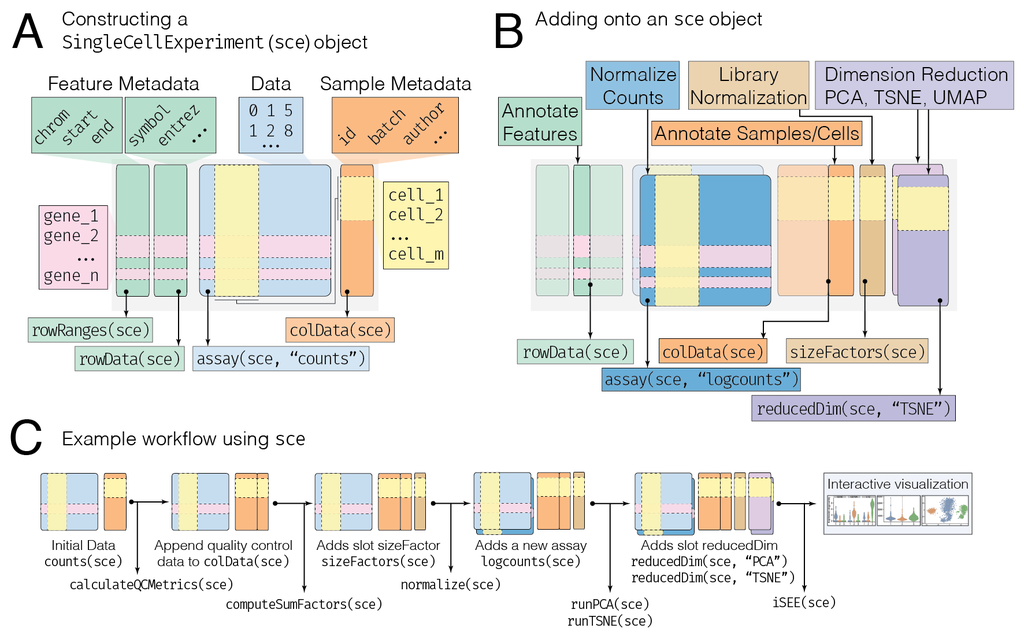

Figure 1. Overview of the SingleCellExperiment object

## Primary Data: The `assays` Slot

```r
counts_matrix <- data.frame(cell_1 = rpois(10, 10),
                    cell_2 = rpois(10, 10),
                    cell_3 = rpois(10, 30))
rownames(counts_matrix) <- paste0("gene_", 1:10)
counts_matrix <- as.matrix(counts_matrix) # must be a matrix object!
```

From this, we can now construct our first SingleCellExperiment object, using the defined constructor, SingleCellExperiment(). Note that we provide our data as a named list, and each entry of the list is a matrix. Here, we name the counts_matrix entry as simply counts within the list.

```r
sce <- SingleCellExperiment(assays = list(counts = counts_matrix))
sce
```

```
## class: SingleCellExperiment
## dim: 10 3
## metadata(0):
## assays(1): counts
## rownames(10): gene_1 gene_2 ... gene_9 gene_10
## rowData names(0):
## colnames(3): cell_1 cell_2 cell_3
## colData names(0):
## reducedDimNames(0):
## spikeNames(0):
```

To access the count data we just supplied, we can do any one of the following:

`assay(sce, "counts")` - this is the most general method, where we can supply the name of the assay as the second argument. `counts(sce)` - this is the same as the above, but only works for assays with the special name “counts”.

```r
assay(sce, "counts")
```

```
##         cell_1 cell_2 cell_3
## gene_1       7      8     27
## gene_2       7      6     37
## gene_3      10     11     24
## gene_4      11     11     26
## gene_5      11     11     21
## gene_6      10     11     34
## gene_7      17      6     34
## gene_8       6     12     28
## gene_9       9      6     38
## gene_10      7      6     32
```

### Extending the assays Slot

the assay slot can hold multiple representations of the primary data, certain slots expect numeric matrices, whereas others may expect data frames.

```r
sce <- scran::computeSumFactors(sce)
sce <- scater::normalize(sce)
sce
```

```
## class: SingleCellExperiment
## dim: 10 3
## metadata(1): log.exprs.offset
## assays(2): counts logcounts
## rownames(10): gene_1 gene_2 ... gene_9 gene_10
## rowData names(0):
## colnames(3): cell_1 cell_2 cell_3
## colData names(0):
## reducedDimNames(0):
## spikeNames(0):
```

### Column (Meta)Data: `colData` Slot

To further annotate our sce object, one of the first and most useful pieces of information is adding on metadata that describes the columns of our primary data, e.g. describing the samples or cells of our experiment. This data is entered into the `colData` slot:

```r
cell_metadata <- data.frame(batch = c(1, 1, 2))
rownames(cell_metadata) <- paste0("cell_", 1:3)
```

```r
## From scratch:
sce <- SingleCellExperiment(assays = list(counts = counts_matrix),
                           colData = cell_metadata)

## Appending to existing object (requires DataFrame() coercion)
# colData(sce) <- DataFrame(cell_metadata)
```

```r
sce <- scater::calculateQCMetrics(sce)
```

#### Using colData for Subsetting

A common operation with colData is its use in subsetting. One simple way to access colData is through the use of the $ operator, which is a shortcut for accessing a variable within the colData slot:

```r
sce$batch
```

```
## [1] 1 1 2
```

If we only wanted cells within batch 1, we could subset our sce object as follows (remember, we subset on the columns in this case because we are filtering by cells/samples here).

```r
sce[, sce$batch == 1]
```

```
## class: SingleCellExperiment
## dim: 10 2
## metadata(0):
## assays(1): counts
## rownames(10): gene_1 gene_2 ... gene_9 gene_10
## rowData names(7): is_feature_control mean_counts ... total_counts
##   log10_total_counts
## colnames(2): cell_1 cell_2
## colData names(10): batch is_cell_control ...
##   pct_counts_in_top_200_features pct_counts_in_top_500_features
## reducedDimNames(0):
## spikeNames(0):
```

### Feature Metadata: rowData/rowRanges

Lastly, the rows also have their own metadata slot to store information that pertains to the features of the sce object: